# Regression Analysis

6. Weighted Regression | Special Lecture for KINS

Boncho Ku, Ph.D. in Statistics

secondmoon@kiom.re.kr

Digital Health Research Division

Korea Institute of Oriental Medicine

2026-09-01

# Weighted Regression

## 이 장의 출발점

### 질문

**앞 장에서 여기까지**: 진단에서 잔차가 깔때기 모양으로 퍼지면 등분산 위반. **이 장의 질문**: 그때 어떤 방법을 사용하는가

모든 관측값을 동일한 신뢰도로 취급해야 하는가?

### 핵심

- 계측기마다 교정 성적서에 적힌 **측정 불확도**가 다름
- 관측값이 서로 다른 횟수의 반복 측정을 평균한 값일 수 있음
- 관측별 신뢰도를 모형에 반영하는 장치가 필요함: 가중치 $w_i$
- 추정 대상인 조건부 기댓값 $E(y \mid x)$ 자체는 바뀌지 않음. 관측마다 주는 가중치만 달라짐

**기호**

- $w_i$: $i$번째 관측에 부여하는 가중치
- 그 관측이 추정에 미치는 영향의 크기를 조절

## 등분산과 이분산: 정의

### 아래첨자 $i$ 의 유무

**등분산(homoscedasticity)**: 모든 $i=1,\dots,n$에 대해 $\operatorname{Var}(\varepsilon_i)=\sigma^2$. 오차의 분산이 공통

**이분산(heteroscedasticity)**: $\operatorname{Var}(\varepsilon_i)=\sigma_i^2$. 오차의 분산이 관측마다 다름

**기호**

- $\varepsilon_i$: $i$번째 관측의 오차. 참 직선에서 그 관측이 위아래로 벗어난 양
- $\operatorname{Var}$: 분산. 값들이 평균에서 흩어진 정도를 재는 수치
- $\sigma^2$: 모든 관측에 공통인 오차 분산
- $\sigma_i^2$: 관측마다 달라지는 오차 분산
- $n$: 관측 수

두 식의 차이는 아래첨자 $i$ 하나뿐이지만, 뒤에서 볼 결과의 차이는 작지 않음

## 등분산과 이분산: 깔때기 신호

### 잔차 그림으로 확인

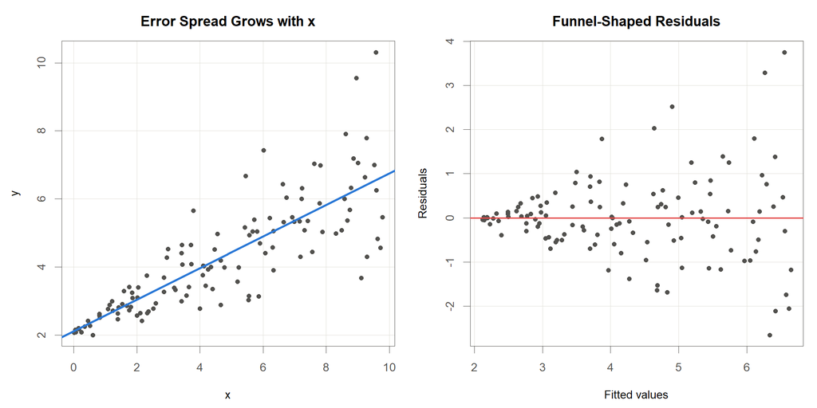

Simulated data with error spread growing in x (funnel-shaped residuals)

**이분산의 전형적 신호**

- 산점도: $x$가 커질수록 점들이 직선 주위로 넓게 퍼짐
- 잔차 그림: 왼쪽은 좁고 오른쪽은 넓은 **깔때기 모양**
- 등분산이면 잔차가 위아래로 고른 띠를 이룸

등분산은 자료가 저절로 만족해 주는 성질이 아니라 분석자가 걸어 둔 가정이므로, Diagnosis 장의 잔차 그림으로 확인해야 함

## 등분산 위반: Gauss-Markov 복습

### OLS가 최선이었던 근거

**Gauss-Markov 정리**: 다음 두 조건이 성립하면 통상최소제곱 추정량 $\hat{\boldsymbol\beta}_{OLS}$는 BLUE이다.

$$E(\boldsymbol\varepsilon \mid \mathbf X)=\mathbf 0, \qquad \operatorname{Var}(\boldsymbol\varepsilon \mid \mathbf X)=\sigma^2\mathbf I$$

**기호**

- $\boldsymbol\varepsilon$: 오차를 세로로 쌓은 $n\times 1$ 벡터
- $\mathbf X$: 절편열을 포함한 $n\times(p+1)$ 설계행렬
- $\mathbf I$: $n\times n$ 항등행렬
- 둘째 조건 = **등분산**(모든 오차의 분산이 $\sigma^2$ 로 같음) + **무상관**(서로 다른 관측의 오차가 함께 움직이지 않음)

**BLUE(Best Linear Unbiased Estimator)**: $y$의 선형결합으로 만든 불편 추정량 가운데 분산이 가장 작은 것. **불편**은 같은 실험을 무수히 반복했을 때 추정값의 평균이 참값과 일치한다는 뜻

## 등분산 위반: 무너지는 결론

### 불편이나 최소분산 아님

이분산에서는 $\operatorname{Var}(\boldsymbol\varepsilon)=\sigma^2\mathbf I$가 성립하지 않으므로 Gauss-Markov 정리의 전제가 무너진다. $\hat{\boldsymbol\beta}_{OLS}$는 **여전히 불편추정량이지만 더 이상 최소분산이 아니다**.

- 편향은 생기지 않음: $E(\hat\beta_1)=\beta_1$이 그대로 성립함
- 최소분산이 아님: 분산이 더 작은 선형 불편 추정량이 존재함
- 표준오차가 왜곡됨: 등분산을 전제로 유도한 공식이기 때문
- 따라서 $t$-검정, $p$-값, 신뢰구간이 모두 틀어짐 (Kutner et al., 2005)

**기호**

- $\hat\beta_1$: 기울기의 추정량, $\beta_1$: 그 참값
- **표준오차**: 추정값이 표본마다 얼마나 흔들리는지를 재는 수치
- **$p$-값**: “기울기가 0이다”라는 가정이 옳다고 볼 때 지금 자료만큼 극단적인 결과가 나올 확률

## 가중최소제곱(WLS): 목적함수

### 정의

가중최소제곱(weighted least squares)은 다음 **가중 잔차제곱합**을 최소화하는 값을 추정량으로 택한다.

$$\min_{\beta_0,\,\beta_1}\ \sum_{i=1}^{n} w_i\left(y_i-\beta_0-\beta_1 x_i\right)^2$$

**기호**

- $y_i$: 반응변수, $x_i$: 설명변수
- $\beta_0,\beta_1$: 절편과 기울기
- $w_i$: $i$번째 관측의 가중치, $n$: 관측 수

### 핵심

- 이론적 최적 가중치는 오차 분산의 역수: $w_i = 1/\sigma_i^2$
- 분산이 작은(정밀한) 관측일수록 큰 $w_i$를 받음
- 모든 $w_i=1$이면 통상최소제곱과 같음: **OLS는 WLS의 특수한 경우**
- 가중치는 비율만 의미를 가짐. 전체에 같은 상수를 곱해도 추정값은 불변

## 가중최소제곱(WLS): 행렬 해

### OLS 공식에 $\mathbf W$ 삽입

$$\hat{\boldsymbol\beta}_W=(\mathbf X^\top \mathbf W \mathbf X)^{-1}\mathbf X^\top \mathbf W \mathbf y$$

**기호**

- $\mathbf y$: 반응변수를 세로로 쌓은 $n\times 1$ 벡터
- $\mathbf X$: 절편열을 포함한 $n\times(p+1)$ 설계행렬
- $\mathbf W=\operatorname{diag}(w_1,\dots,w_n)$: 가중치를 대각선에 놓고 나머지 자리를 0으로 채운 대각행렬
- $\hat{\boldsymbol\beta}_W$: 가중최소제곱 추정량

OLS 공식 $(\mathbf X^\top\mathbf X)^{-1}\mathbf X^\top\mathbf y$ 와 비교하면 $\mathbf X$ 와 $\mathbf y$ 사이에 $\mathbf W$ 가 끼어든 형태. $\mathbf W=\mathbf I$ 이면 OLS로 되돌아감

## 가중최소제곱(WLS): 해의 유도

### 절차는 OLS와 동일

가중 잔차제곱합을 행렬로 쓰면

$$S_W(\boldsymbol\beta)=\sum_{i=1}^{n} w_i\left(y_i-\mathbf x_i^\top\boldsymbol\beta\right)^2=(\mathbf y-\mathbf X\boldsymbol\beta)^\top\mathbf W(\mathbf y-\mathbf X\boldsymbol\beta)$$

$\boldsymbol\beta$로 미분해 $\mathbf 0$으로 놓으면 정규방정식을 얻음

$$\frac{\partial S_W}{\partial\boldsymbol\beta}=-2\,\mathbf X^\top\mathbf W(\mathbf y-\mathbf X\boldsymbol\beta)=\mathbf 0
\ \Longrightarrow\ \mathbf X^\top\mathbf W\mathbf X\,\hat{\boldsymbol\beta}_W=\mathbf X^\top\mathbf W\mathbf y$$

$\mathbf X^\top\mathbf W\mathbf X$ 가 가역이면 앞 슬라이드의 해

**기호**

- $\mathbf x_i^\top$: 설계행렬 $\mathbf X$ 의 $i$번째 행
- $S_W(\boldsymbol\beta)$: 가중 잔차제곱합

## 가중치를 정하는 규칙

### 실무 규칙

Practical rules for choosing weights (Kutner et al., 2005)

| Situation | Weight $w_i$ |
| --- | --- |
| 측정 분산 $\sigma_i^2$를 아는 경우(교정 성적서, 반복 측정) | $w_i = 1/\sigma_i^2$ |
| $y_i$가 $n_i$개 측정값의 평균인 경우 | $w_i = n_i$ |
| 퍼짐이 $x_i$에 비례해 커지는 경우 | $w_i \propto 1/x_i$ |

**기호**

- $\sigma_i^2$: $i$번째 관측의 오차 분산
- $n_i$: $y_i$ 를 만들 때 평균한 측정 횟수
- $\propto$: “비례한다”는 기호

### 핵심

세 규칙은 모두 하나의 원리에서 나온다: **가중치는 분산의 역수**. $n_i$개 측정값을 평균하면 그 평균의 분산이 $\sigma^2/n_i$이므로, 역수를 취하면 $w_i \propto n_i$가 된다.

## 가중치의 실무 적용: 감마선 검교정

### 분산을 이미 아는 경우

Introduction 장에서 소개한 사례가 앞 표의 첫째 줄에 해당함

- 검출기의 검출 효율 곡선을 적합하는 검교정 문제
- 각 측정점의 분산이 **계수 통계(counting statistics)**로 이미 알려져 있음
- 따라서 가중치를 추정하지 않고 곧바로 계산함: $w_i = 1/\sigma_i^2$
- 오차 분산을 알고 오차가 서로 무상관이면, 역분산 가중이 선형 불편 추정량 가운데 최소분산을 줌

**기호**

- $\sigma_i$: $i$번째 측정점 계수율의 표준편차
- 계수 통계에서 곧바로 계산되는 값

*Analytical Chemistry* 91(7) (2019), doi:10.1021/acs.analchem.9b00119. / INMM Annual Meeting Proceedings, “Weighted Least Squares Fitting of Gamma Spectroscopy Efficiency Functions”.

## 예제 자료(물리 측정): 자료 구조

### $w$ 는 분산에 비례

First 3 rows of the physics data. n = 10 observations, 3 variables (CNU lecture note, Example 8.1)

| x | y | w |
| --- | --- | --- |
| 0.345 | 367 | 17 |
| 0.287 | 311 | 9 |
| 0.251 | 295 | 9 |

- 양자충돌 실험 자료, $n=10$
- $x$는 설명변수, $y$는 반응변수인 측정값
- $w$는 각 $y$의 **측정 분산에 비례**하는 값. 분산 자체가 아니라 분산에 비례하는 값
- 따라서 가중치는 그 역수인 $1/w$가 됨. $w$ 가 클수록 신뢰도가 낮은 점

## 예제 자료(물리 측정): OLS와 WLS 비교

### 두 직선의 차이

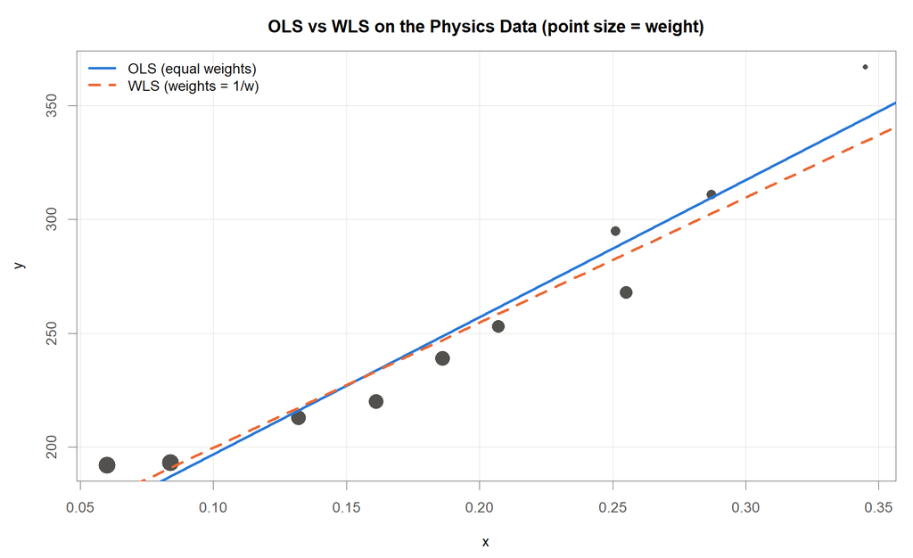

OLS vs WLS fits on the physics data; point size is proportional to weight

**읽는 법**

- 점의 크기가 가중치 $1/w$에 비례함
- 큰 점일수록 정밀하게 측정된 점
- 실선은 모든 점을 동일하게 취급한 OLS
- 점선은 가중치를 반영한 WLS
- 두 직선이 갈라지는 이유는 WLS가 큰 점 쪽으로 더 기울기 때문

## 예제 자료(물리 측정): 추정 결과

### 계수와 표준오차의 변화

**추정 경로**

자료에 기록된 $w_i$ 는 각 $y_i$ 의 **측정분산**. 가중치는 그 역수이므로

$$\mathbf W=\operatorname{diag}\!\Big(\frac{1}{w_1},\dots,\frac{1}{w_{10}}\Big),
\qquad
\hat{\boldsymbol\beta}_{\mathrm{WLS}}=(\mathbf X^\top\mathbf W\mathbf X)^{-1}\mathbf X^\top\mathbf W\mathbf y$$

$$\operatorname{Var}(\hat{\boldsymbol\beta}_{\mathrm{WLS}})=\sigma^2(\mathbf X^\top\mathbf W\mathbf X)^{-1}$$

$\mathbf W=\mathbf I$ 로 두면 두 식이 그대로 OLS의 $(\mathbf X^\top\mathbf X)^{-1}\mathbf X^\top\mathbf y$ 와 $\sigma^2(\mathbf X^\top\mathbf X)^{-1}$ 이 됨. OLS는 모든 관측에 동일한 가중치를 부여한 WLS

**추정 결과**

OLS vs WLS estimates on the physics data (n = 10). WLS $R^2 = 0.929$

| Estimate | OLS | WLS |
| --- | --- | --- |
| $\hat\beta_0$ (intercept) | 136.6 (SE 11.9) | 144.8 (SE 10.3) |
| $\hat\beta_1$ (slope) | 602.4 (SE 55.6) | 549.5 (SE 53.6) |

**결과 읽기**

- 기울기 추정: 602.4에서 549.5로 이동함
- 표준오차: 절편은 11.9에서 10.3으로, 기울기는 55.6에서 53.6으로 감소함
- WLS 적합의 결정계수는 $R^2 = 0.929$
- 표준오차의 감소 폭보다, 분산 구조를 반영한 표준오차를 쓰게 되었다는 점이 중요함

## 감쇠 곡선: 문제 설정

### 가중치를 아는 문제

**유도**

감쇠는 Beer-Lambert 형태로, 로그를 취하면 선형이 되고 **기울기의 음수가 감쇠계수** $\mu$

$$N(x)=N_0\,e^{-\mu x}\qquad\Longrightarrow\qquad \ln N(x)=\ln N_0-\mu x$$

계수는 Poisson을 따르므로 $\operatorname{Var}(N)=N$. 여기에 델타법을 적용하면

$$\operatorname{Var}(\ln N)\;\approx\;\Big(\frac{d\ln N}{dN}\Big)^{2}\operatorname{Var}(N)=\frac{1}{N^{2}}\cdot N=\frac{1}{N}$$

- 델타법: 함수 $g(N)$ 의 분산을 $\{g'(N)\}^2\operatorname{Var}(N)$ 로 근사하는 방법
- 흡수체가 두꺼워져 계수가 줄수록 $\ln N$ 의 분산이 **커짐**. 로그 변환이 이분산을 만들어 냄
- 그 크기가 이론으로 이미 알려져 있으므로 가중치는 곧바로 $w_i=1/\operatorname{Var}(\ln N_i)=N_i$
- 앞의 규칙 표 첫째 줄(분산을 아는 경우)에 그대로 해당

## 감쇠 곡선: 분산의 증가

### 모의실험 $\mu=1.25\ \mathrm{cm^{-1}}$, $N_0=20000$

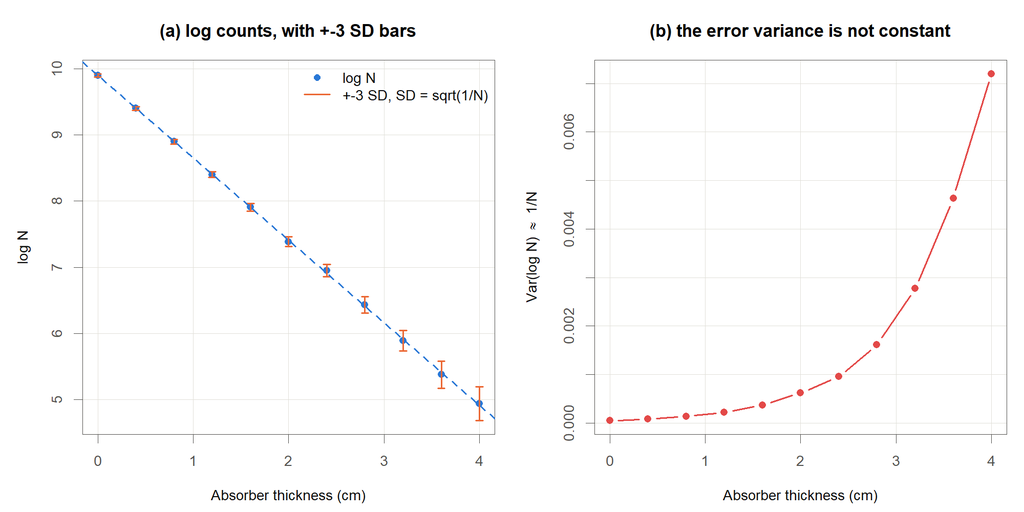

(a) log counts with plus or minus 3 SD bars. (b) Var(log N) against absorber thickness.

One simulated attenuation experiment; the error variance grows 143-fold across the range

| Thickness (cm) | 0.0 | 1.2 | 2.4 | 3.6 | 4.0 |
| --- | --- | --- | --- | --- | --- |
| Counts $N$ | 19920 | 4449 | 1046 | 216 | 139 |
| $\operatorname{Var}(\ln N)=1/N$ | 0.000050 | 0.000225 | 0.000956 | 0.004630 | 0.007194 |

## 감쇠 곡선: OLS와 WLS 비교

### 2000회 반복에서의 $\hat\mu$ 분포

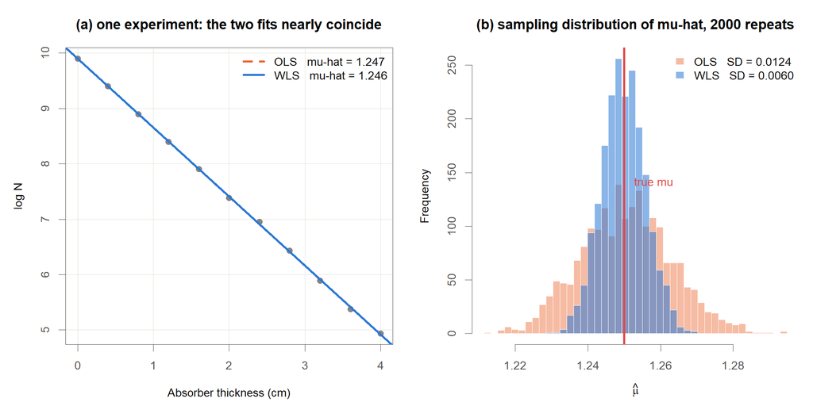

(a) One experiment: the two fits nearly coincide. (b) Sampling distribution of the estimated attenuation coefficient over 2000 repeats.

Recovery of the true attenuation coefficient over 2000 simulated experiments

| Method | Bias | SD | RMSE |
| --- | --- | --- | --- |
| 로그 계수에 OLS | +0.0005 | 0.0124 | 0.0124 |
| **로그 계수에 WLS** ($w_i=N_i$) | −0.0002 | **0.0060** | **0.0060** |

둘 다 편향은 없으나 **WLS의 분산이 4.3배 작음**. 같은 측정으로 $\mu$ 를 두 배 이상 정밀하게 얻는다는 뜻

## 감쇠 곡선: WLS의 한계

### 최대가능도로의 전환

가중치로 쓰는 $N_i$ 가 **관측값 자체**이므로, 계수가 적으면 가중치와 자료가 음의 상관을 갖게 되어 편향이 생김

Bias in the estimated attenuation coefficient as the weakest signal gets smaller (2000 repeats each)

[output not shown]

**실무 지침**

- 계수가 수십 이상: 로그 변환 후 $w_i=N_i$ 로 **WLS**
- 계수가 한 자리로 떨어짐: 로그를 취하지 말고 **Poisson 최대가능도**(로그연결 GLM)로 직접 적합
- 계수가 0인 점: 로그가 정의되지 않으므로 WLS 자체가 불가능. GLM은 그대로 처리 가능

## 일반화최소제곱(GLS): 정의

### 오차 간 상관의 포함

오차의 공분산행렬이 $\operatorname{Var}(\boldsymbol\varepsilon)=\boldsymbol\Sigma$인 선형모형 $\mathbf y=\mathbf X\boldsymbol\beta+\boldsymbol\varepsilon$에서, 일반화최소제곱 추정량은 다음과 같다.

$$\hat{\boldsymbol\beta}_{GLS}=(\mathbf X^\top\boldsymbol\Sigma^{-1}\mathbf X)^{-1}\mathbf X^\top\boldsymbol\Sigma^{-1}\mathbf y$$

**기호**

- $\boldsymbol\Sigma$: 오차 벡터 $\boldsymbol\varepsilon$ 의 공분산행렬. 대칭이고 양정치
- 대각 원소: 각 오차의 분산
- 비대각 원소: 두 오차가 함께 움직이는 정도인 공분산
- 나머지 기호는 앞 슬라이드와 동일

WLS 공식에서 $\mathbf W$ 자리에 $\boldsymbol\Sigma^{-1}$ 이 들어간 형태

## 일반화최소제곱(GLS): 유도

### 변환을 통해 OLS로 환원

$\boldsymbol\Sigma^{-1}=\mathbf P^\top\mathbf P$를 만족하는 대칭행렬 $\mathbf P$를 잡아 모형의 양변에 곱하면

$$\mathbf P\mathbf y=\mathbf P\mathbf X\boldsymbol\beta+\mathbf P\boldsymbol\varepsilon,\qquad
\operatorname{Var}(\mathbf P\boldsymbol\varepsilon)=\mathbf P\boldsymbol\Sigma\mathbf P^\top=\mathbf I$$

변환된 자료는 등분산과 무상관을 모두 만족. 여기에 **통상최소제곱**을 그대로 적용하면 앞 슬라이드의 GLS 해

**기호**

- $\mathbf P$: $\boldsymbol\Sigma^{-1}$ 을 분해해 얻는 변환행렬
- $\mathbf I$: 항등행렬

## 일반화최소제곱(GLS): WLS와의 관계

### 핵심

- WLS는 $\boldsymbol\Sigma$가 **대각행렬**인 특수한 경우. 오차 사이의 상관을 나타내는 비대각 원소가 모두 0
- $\boldsymbol\Sigma=\sigma^2\mathbf I$이면 GLS와 WLS와 OLS가 모두 일치함
- $\boldsymbol\Sigma$를 알 때 GLS가 BLUE라는 결과가 Gauss-Markov 정리의 일반화임(Aitken 정리)

### 자기상관 구조의 예

시간 순서로 이웃한 오차가 서로 닮아 있는 성질을 **자기상관**이라 함. 한 칸 멀어질 때마다 상관이 $\rho$ 배로 줄어드는 구조가 가장 단순한 예

$$\boldsymbol\Sigma=\sigma^2\begin{pmatrix}
1 & \rho & \rho^2 & \cdots & \rho^{\,n-1}\\
\rho & 1 & \rho & \cdots & \rho^{\,n-2}\\
\rho^2 & \rho & 1 & \cdots & \rho^{\,n-3}\\
\vdots & \vdots & \vdots & \ddots & \vdots\\
\rho^{\,n-1} & \rho^{\,n-2} & \rho^{\,n-3} & \cdots & 1
\end{pmatrix},\qquad |\rho|<1$$

$\rho=0$ 이면 비대각 원소가 모두 사라져 $\boldsymbol\Sigma=\sigma^2\mathbf I$, 곧 OLS로 되돌아감

## GLS 예제: Lake Huron 수위

### 98년 연간 기록의 추세

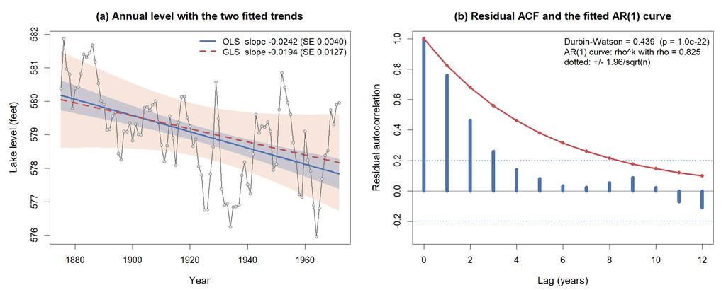

(a) Annual lake level 1875-1972 with the OLS and GLS trends and their 95% confidence bands. (b) Residual ACF against the fitted AR(1) curve.

Autocorrelation in the OLS residuals of the Lake Huron trend model (n = 98 annual measurements)

| Quantity | Value | 뜻 |
| --- | --- | --- |
| Durbin-Watson $d$ | 0.4395 ($p=1.0\times10^{-22}$) | 2에서 아래로 크게 벗어남 |
| Residual ACF, lags 1-3 | 0.762, 0.464, 0.261 | 이웃 해의 잔차가 강하게 닮아 있음 |
| Runs of one sign | 19 | 98개 잔차에서 부호가 18번만 바뀜 |

- $d=\sum_{t=2}^{n}(e_t-e_{t-1})^2\big/\sum_{t=1}^{n}e_t^2$: **Durbin-Watson 통계량**
- 이웃한 잔차가 무관하면 2 부근, 같은 방향으로 움직이면 2보다 작아짐
- 퍼짐은 고르므로 등분산은 유지되고, $\operatorname{Var}(\boldsymbol\varepsilon)=\sigma^2\mathbf I$ 의 **무상관** 쪽만 깨져 있음

## GLS 예제: 풀이 절차

### 세 단계

1. **구조를 고른다.** 앞 슬라이드의 AR(1)을 그대로 씀. 관측이 98개면 공분산행렬의 칸이 9604개이므로, 모양을 정해 추정할 값을 $\rho$ 하나로 줄임
   $$\boldsymbol\Sigma=\sigma^2\mathbf V,\qquad V_{ij}=\rho^{\,|i-j|}$$
2. **$\rho$ 를 추정한다.** 서로 다른 세 방법이 거의 같은 값을 줌: Cochrane-Orcutt 반복 0.768, 최대가능도 0.783, 제한최대가능도 0.825. **추정 방법이 결과를 좌우하지 않는다는 확인**이며, 이후 계산은 $\hat\rho=0.825$ 를 사용
3. **공식에 넣는다.** $\hat{\boldsymbol\beta}_{GLS}=(\mathbf X^\top\mathbf V^{-1}\mathbf X)^{-1}\mathbf X^\top\mathbf V^{-1}\mathbf y$ 로 계산. $\rho=0$ 을 검정하는 가능도비는 $\chi^2_1=89.6$, $p<0.0001$ 로 자기상관 항을 넣을 근거가 뚜렷함

$\boldsymbol\Sigma$ 를 몰라 자료에서 추정해 쓰므로 **실행가능 GLS(feasible GLS)**. Aitken 정리의 BLUE 보장은 근사적으로만 성립

## GLS 예제: OLS와 GLS 비교

### 기울기는 그대로, 표준오차는 3배

OLS vs feasible GLS on the Lake Huron trend model (n = 98, df = 96)

| Estimate | OLS | GLS (AR(1), $\hat\rho=0.825$) |
| --- | --- | --- |
| $\hat\beta_0$ (intercept) | 625.555 (SE 7.764) | 616.489 (SE 24.363) |
| $\hat\beta_1$ (slope, feet/year) | $-0.02420$ (SE 0.00404) | $-0.01943$ (SE 0.01266) |
| $t$ for the slope | $-6.00$ | $-1.53$ |
| $p$ for the slope | $3.5\times 10^{-8}$ | 0.128 |
| 95% CI for the slope | $[-0.0322,\ {-0.0162}]$ | $[-0.0446,\ {+0.0057}]$ |

**읽는 법**

- 기울기 추정값은 $-0.0242$ 에서 $-0.0194$ 로 조금 움직였을 뿐. **바뀐 것은 정밀도의 평가**
- 표준오차가 **3.14배**로 커지고 신뢰구간도 같은 배율로 넓어져 0을 포함하게 됨
- 결론이 뒤집힘: OLS는 하강 추세가 $p=3.5\times10^{-8}$ 로 확실하다고 하지만, GLS는 $p=0.128$ 로 **유의하지 않다**고 함
- 원인은 정보량의 과대계산. 이웃 해의 값이 서로 닮아 있으면 실제 독립 정보는 98년치보다 적은데, OLS 공식은 98개를 전부 독립으로 셈

**주의**: AR(1)은 근사. 그림 (b)에서 붉은 곡선이 lag 2 이상에서 실제 ACF보다 위에 있고, 변환 뒤에도 lag-1 상관이 0.19 남음. 이 자료에는 AR(2) 계열이 더 맞는다고 알려져 있으나, **결론의 방향은 바뀌지 않음**

## 이 장의 정리

### 정리

- 이분산이면 OLS는 편향은 없지만 **최소분산이 아니고, 표준오차가 틀어짐**
- 처방은 WLS: $\min\sum w_i(y_i-\beta_0-\beta_1x_i)^2$, 해는 $(\mathbf X^\top\mathbf W\mathbf X)^{-1}\mathbf X^\top\mathbf W\mathbf y$
- 이론적 최적 가중치는 분산의 역수 $w_i=1/\sigma_i^2$이며, 가중치에는 근거가 있어야 함
- 오차 사이의 상관까지 있으면 GLS로 확장함: $\mathbf W$ 자리에 $\boldsymbol\Sigma^{-1}$

### 실무 적용

측정 불확도가 기록되어 있다면 그 분산의 역수를 가중치 $w_i=1/\sigma_i^2$ 로 삼는다.

기호는 이 장에서 정의한 것과 같음($w_i$ 가중치, $\sigma_i^2$ 관측별 오차 분산, $\mathbf W$ 가중치 대각행렬, $\boldsymbol\Sigma$ 오차 공분산행렬)

**다음 장**: Dummy Variable: 아이스크림 자료의 관측 연차처럼 숫자로 계산하면 안 되는 정보를 모형에 넣는 방법

## 참고문헌

### 이 장에서 인용한 문헌

- Kutner, M. H., et al. (2005). *Applied Linear Statistical Models*, 5th ed. McGraw-Hill. (이분산의 결과, 가중치 선택 규칙, 자기상관과 Cochrane-Orcutt 절차)
- *Analytical Chemistry*, 91(7) (2019). doi:10.1021/acs.analchem.9b00119
- INMM Annual Meeting Proceedings. Weighted least squares fitting of gamma spectroscopy efficiency functions.
- Brockwell, P. J., & Davis, R. A. (1991). *Time Series: Theory and Methods*, 2nd ed. Springer, p. 555. (GLS 예제의 Lake Huron 자료. R의 `datasets::LakeHuron` 이 출처로 드는 문헌)

### 교과서

- Kutner, M. H., Nachtsheim, C. J., Neter, J., & Li, W. (2005). *Applied Linear Statistical Models*, 5th ed. McGraw-Hill.
- Faraway, J. J. (2015). *Linear Models with R*, 2nd ed. CRC Press.